# AI Investment Decision Engine

## Machine Learning-Based Stock Market Prediction

**Author:** Alex Alvarez  
**Project Type:** Python / Machine Learning / Financial Analytics

### Project Overview

This project develops a machine learning workflow to analyze NVIDIA (NVDA) historical stock data and estimate the next trading day's market direction. Historical market data is collected from Yahoo Finance, transformed into predictive features, and used to train and compare multiple machine learning models.

### Objectives

- Download historical stock market data
- Engineer technical indicators such as daily returns and moving averages
- Visualize price trends and trading signals
- Train multiple machine learning models
- Compare model performance
- Generate a next-day directional prediction

### Models Used

- Logistic Regression
- Random Forest
- XGBoost

## 1. Import Libraries

This section imports the Python libraries used for data collection, data analysis, visualization, and machine learning.

```python
import yfinance as yf
import pandas as pd
```

## 2. Download Historical Stock Data

Historical NVIDIA stock data is downloaded from Yahoo Finance using the `yfinance` package.

```python
nvda = yf.download("NVDA" , start="2023-01-01")

print(nvda.head())
```

```
Price           Close       High        Low       Open     Volume
Ticker           NVDA       NVDA       NVDA       NVDA       NVDA
Date
2023-01-03  14.283261  14.962752  14.064747  14.818073  401277000
2023-01-04  14.716302  14.820071  14.209429  14.534706  431324000
2023-01-05  14.233374  14.531711  14.116632  14.458872  389168000
2023-01-06  14.826057  14.976723  14.002887  14.441911  405044000
2023-01-09  15.593353  16.020404  15.107432  15.250116  504231000
```

## 3. Exploratory Data Analysis

This section reviews the size of the dataset and key summary statistics such as highest, lowest, and average closing price.

```python
print("Number of trading days:", len(nvda))
print("Highest closing price:", nvda["Close"].max())
print("Lowest closing price:", nvda["Close"].min())
print("Average closing price:", nvda["Close"].mean())
```

```
Number of trading days: 877
Highest closing price: Ticker
NVDA    235.465576
dtype: float64
Lowest closing price: Ticker
NVDA    14.233374
dtype: float64
Average closing price: Ticker
NVDA    112.865484
dtype: float64
```

## 4. Initial Price Visualization

A basic line chart is created to visualize the historical closing price trend.

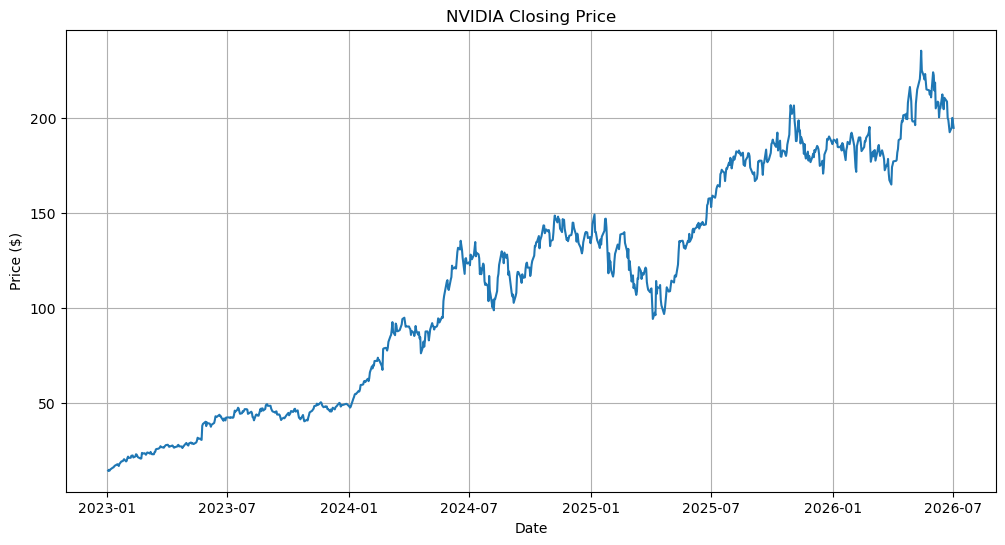

```python
import matplotlib.pyplot as plt

plt.figure(figsize=(12,6))

plt.plot(nvda["Close"])

plt.title("NVIDIA Closing Price")

plt.xlabel("Date")

plt.ylabel("Price ($)")

plt.grid(True)

plt.show()
```

## 5. Summary Statistics

This section summarizes the number of observations and key price statistics.

```python
print("Number of Trading Days:", len(nvda))
print()

print("Highest Closing Price:")
print(nvda["Close"].max())
print()

print("Lowest Closing Price:")
print(nvda["Close"].min())
print()

print("Average Closing Price:")
print(nvda["Close"].mean())
```

```
Number of Trading Days: 877

Highest Closing Price:
Ticker
NVDA    235.465576
dtype: float64

Lowest Closing Price:
Ticker
NVDA    14.233374
dtype: float64

Average Closing Price:
Ticker
NVDA    112.865484
dtype: float64
```

## 6. Latest Closing Price

The most recent closing price is extracted from the dataset.

```python
print("Latest Closing Price:")

print(nvda["Close"].iloc[-1])
```

```
Latest Closing Price:
Ticker
NVDA    194.830002
Name: 2026-07-02 00:00:00, dtype: float64
```

## 7. Daily Returns

Daily returns are calculated to measure day-to-day percentage changes in the stock price.

```python
nvda["Daily Return"] = nvda["Close"].pct_change()

print(nvda.head(10))
```

```
Price           Close       High        Low       Open     Volume Daily Return
Ticker           NVDA       NVDA       NVDA       NVDA       NVDA
Date
2023-01-03  14.283261  14.962752  14.064747  14.818073  401277000          NaN
2023-01-04  14.716302  14.820071  14.209429  14.534706  431324000     0.030318
2023-01-05  14.233374  14.531711  14.116632  14.458872  389168000    -0.032816
2023-01-06  14.826057  14.976723  14.002887  14.441911  405044000     0.041640
2023-01-09  15.593353  16.020404  15.107432  15.250116  504231000     0.051753
2023-01-10  15.873730  15.926612  15.437698  15.472621  384101000     0.017981
2023-01-11  15.965526  15.992466  15.528497  15.804883  353285000     0.005783
2023-01-12  16.474392  16.600112  15.457651  16.064304  551409000     0.031873
2023-01-13  16.861534  16.884484  16.129162  16.241911  447287000     0.023500
2023-01-17  17.662754  17.688697  16.861535  16.861535  511102000     0.047518
```

## 8. Best and Worst Trading Days

This section identifies the largest daily gain and largest daily loss in the dataset.

```python
print("Best Daily Return:")
print(nvda["Daily Return"].max())

print()

print("Worst Daily Return:")
print(nvda["Daily Return"].min())
```

```
Best Daily Return:
0.24369631772540146

Worst Daily Return:
-0.16968167662348033
```

## 9. Average Daily Return

The average daily return is calculated to estimate the typical daily price movement.

```python
print("Average Daily Return:")

print(nvda["Daily Return"].mean())
```

```
Average Daily Return:
0.0034500817386651584
```

```python
print("Average Daily Return: {:.2%}".format(nvda["Daily Return"].mean()))
```

```
Average Daily Return: 0.35%
```

## 10. Volatility

Volatility is measured using the standard deviation of daily returns.

```python
print("Daily Volatility:")

print(nvda["Daily Return"].std())
```

```
Daily Volatility:
0.03066877022912531
```

## 11. Investment Summary

A summary report is created to present the main financial statistics.

```python
print("========== NVDA INVESTMENT SUMMARY ==========")

print(f"Trading Days: {len(nvda)}")

print(f"Highest Close: ${nvda['Close'].max().iloc[0]:.2f}")
print(f"Lowest Close: ${nvda['Close'].min().iloc[0]:.2f}")
print(f"Average Close: ${nvda['Close'].mean().iloc[0]:.2f}")

print(f"Average Daily Return: {nvda['Daily Return'].mean():.2%}")
print(f"Daily Volatility: {nvda['Daily Return'].std():.2%}")
```

```
========== NVDA INVESTMENT SUMMARY ==========
Trading Days: 877
Highest Close: $235.47
Lowest Close: $14.23
Average Close: $112.87
Average Daily Return: 0.35%
Daily Volatility: 3.07%
```

## 12. Moving Average Feature Engineering

A 20-day moving average is created to smooth short-term price fluctuations.

```python
nvda["MA20"] = nvda["Close"].rolling(window=20).mean()

print(nvda.head(25))
```

```
Price           Close       High        Low       Open     Volume  \
Ticker           NVDA       NVDA       NVDA       NVDA       NVDA
Date
2023-01-03  14.283261  14.962752  14.064747  14.818073  401277000
2023-01-04  14.716302  14.820071  14.209429  14.534706  431324000
2023-01-05  14.233374  14.531711  14.116632  14.458872  389168000
2023-01-06  14.826057  14.976723  14.002887  14.441911  405044000
2023-01-09  15.593353  16.020404  15.107432  15.250116  504231000
2023-01-10  15.873730  15.926612  15.437698  15.472621  384101000
2023-01-11  15.965526  15.992466  15.528497  15.804883  353285000
2023-01-12  16.474392  16.600112  15.457651  16.064304  551409000
2023-01-13  16.861534  16.884484  16.129162  16.241911  447287000
2023-01-17  17.662754  17.688697  16.861535  16.861535  511102000
2023-01-18  17.338476  17.833375  17.243686  17.627832  439624000
2023-01-19  16.727829  17.158872  16.693906  16.998228  452932000
2023-01-20  17.799452  17.816414  16.787700  16.973286  564967000
2023-01-23  19.150452  19.202336  17.778500  18.023953  655163000
2023-01-24  19.222286  19.451778  18.778273  18.785258  496204000
2023-01-25  19.280159  19.327056  18.538806  18.871068  449537000
2023-01-26  19.758097  20.121290  19.235258  19.657321  489535000
2023-01-27  20.319849  20.582266  19.361978  19.418851  542142000
2023-01-30  19.119520  20.095351  19.107546  19.905773  488611000
2023-01-31  19.493687  19.643354  18.907988  19.127500  498017000
2023-02-01  20.896568  21.145015  19.567521  19.647343  660477000
2023-02-02  21.660873  21.900341  20.654111  20.953446  564276000
2023-02-03  21.053221  21.696791  20.742909  20.953442  429366000
2023-02-06  21.042246  21.522178  20.739916  20.759872  452197000
2023-02-07  22.123842  22.209652  21.103110  21.334596  664150000

Price      Daily Return       MA20
Ticker
Date
2023-01-03          NaN        NaN
2023-01-04     0.030318        NaN
2023-01-05    -0.032816        NaN
2023-01-06     0.041640        NaN
2023-01-09     0.051753        NaN
2023-01-10     0.017981        NaN
2023-01-11     0.005783        NaN
2023-01-12     0.031873        NaN
2023-01-13     0.023500        NaN
2023-01-17     0.047518        NaN
2023-01-18    -0.018359        NaN
2023-01-19    -0.035219        NaN
2023-01-20     0.064062        NaN
2023-01-23     0.075901        NaN
2023-01-24     0.003751        NaN
2023-01-25     0.003011        NaN
2023-01-26     0.024789        NaN
2023-01-27     0.028431        NaN
2023-01-30    -0.059072        NaN
2023-01-31     0.019570  17.235004
2023-02-01     0.071966  17.565670
2023-02-02     0.036576  17.912898
2023-02-03    -0.028053  18.253891
2023-02-06    -0.000521  18.564700
2023-02-07     0.051401  18.891225
```

## 13. Price and Moving Average Chart

The closing price and 20-day moving average are plotted together to compare price movement with trend direction.

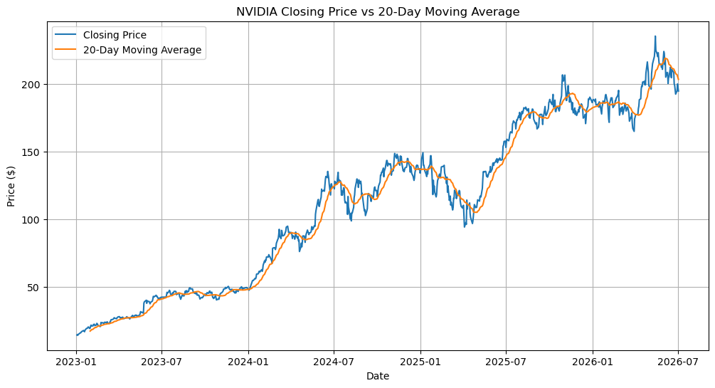

```python
import matplotlib.pyplot as plt

plt.figure(figsize=(12,6))

plt.plot(nvda["Close"], label="Closing Price")

plt.plot(nvda["MA20"], label="20-Day Moving Average")

plt.title("NVIDIA Closing Price vs 20-Day Moving Average")

plt.xlabel("Date")

plt.ylabel("Price ($)")

plt.legend()

plt.grid(True)

plt.show()
```

## 14. Fix Close Price Structure and Add 50-Day Moving Average

The close price column is converted into a clean Series, then 20-day and 50-day moving averages are recalculated.

```python
close = nvda["Close"].iloc[:, 0]

nvda["MA20"] = close.rolling(window=20).mean()
nvda["MA50"] = close.rolling(window=50).mean()

print(nvda[["Close", "MA20", "MA50"]].tail(10))
```

```
Price            Close        MA20        MA50
Ticker            NVDA
Date
2026-06-18  210.690002  211.681020  209.120965
2026-06-22  208.649994  211.150797  209.620046
2026-06-23  200.039993  210.398830  209.852638
2026-06-24  199.000000  209.618336  210.050846
2026-06-25  195.740005  208.787711  210.040021
2026-06-26  192.529999  207.714182  209.917851
2026-06-29  194.970001  206.917971  209.854869
2026-06-30  200.089996  205.717530  209.827765
2026-07-01  197.580002  204.468500  209.742870
2026-07-02  194.830002  203.485000  209.646523
```

## 15. Price with 20-Day and 50-Day Moving Averages

This chart compares the closing price with both short-term and medium-term moving averages.

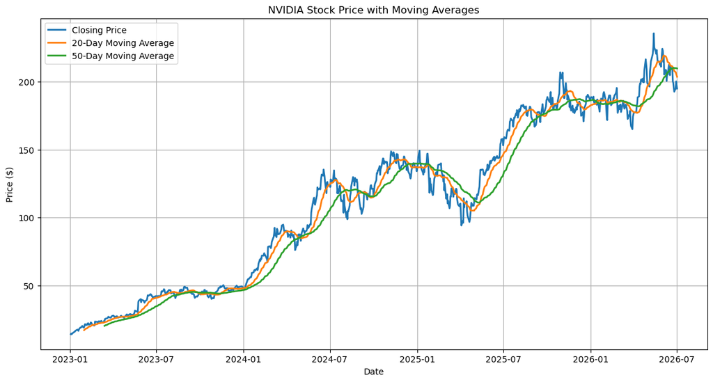

```python
plt.figure(figsize=(14,7))

plt.plot(nvda["Close"], label="Closing Price", linewidth=2)

plt.plot(nvda["MA20"], label="20-Day Moving Average", linewidth=2)

plt.plot(nvda["MA50"], label="50-Day Moving Average", linewidth=2)

plt.title("NVIDIA Stock Price with Moving Averages")

plt.xlabel("Date")

plt.ylabel("Price ($)")

plt.legend()

plt.grid(True)

plt.show()
```

## 16. Final Version 1 Investment Summary

This section summarizes the completed financial analytics portion of the project.

```python
print("=" * 60)
print("AI INVESTMENT DECISION ENGINE - VERSION 1")
print("=" * 60)

print(f"Trading Days: {len(nvda)}")

print(f"Highest Closing Price: ${close.max():.2f}")
print(f"Lowest Closing Price : ${close.min():.2f}")
print(f"Average Closing Price: ${close.mean():.2f}")

print(f"Average Daily Return : {nvda['Daily Return'].mean():.2%}")
print(f"Daily Volatility     : {nvda['Daily Return'].std():.2%}")

print()
print("Moving Averages:")
print("✓ 20-Day Moving Average")
print("✓ 50-Day Moving Average")

print()
print("Project Status:")
print("✓ Downloaded real market data")
print("✓ Explored the dataset")
print("✓ Calculated daily returns")
print("✓ Measured volatility")
print("✓ Built moving averages")
print("✓ Created professional charts")

print("=" * 60)
```

```
============================================================
AI INVESTMENT DECISION ENGINE - VERSION 1
============================================================
Trading Days: 877
Highest Closing Price: $235.47
Lowest Closing Price : $14.23
Average Closing Price: $112.87
Average Daily Return : 0.35%
Daily Volatility     : 3.07%

Moving Averages:
✓ 20-Day Moving Average
✓ 50-Day Moving Average

Project Status:
✓ Downloaded real market data
✓ Explored the dataset
✓ Calculated daily returns
✓ Measured volatility
✓ Built moving averages
✓ Created professional charts
============================================================
```

## 17. Trend Detection

The latest 20-day and 50-day moving averages are compared to classify the current trend.

```python
latest_ma20 = nvda["MA20"].iloc[-1]

latest_ma50 = nvda["MA50"].iloc[-1]

print("Latest 20-Day MA:", round(latest_ma20, 2))
print("Latest 50-Day MA:", round(latest_ma50, 2))
```

```
Latest 20-Day MA: 203.48
Latest 50-Day MA: 209.65
```

## 18. Bullish or Bearish Trend Signal

A simple trend signal is generated based on whether the short-term moving average is above or below the medium-term moving average.

```python
if latest_ma20 > latest_ma50:
    print("Trend Signal: Bullish")
else:
    print("Trend Signal: Bearish")
```

```
Trend Signal: Bearish
```

## 19. Trading Signal Column

A signal column is created for every trading day, labeling each day as Bullish or Bearish.

```python
import numpy as np

nvda["Signal"] = np.where(
    nvda["MA20"] > nvda["MA50"],
    "Bullish",
    "Bearish"
)

print(nvda[["Close", "MA20", "MA50", "Signal"]].tail(10))
```

```
Price            Close        MA20        MA50   Signal
Ticker            NVDA
Date
2026-06-18  210.690002  211.681020  209.120965  Bullish
2026-06-22  208.649994  211.150797  209.620046  Bullish
2026-06-23  200.039993  210.398830  209.852638  Bullish
2026-06-24  199.000000  209.618336  210.050846  Bearish
2026-06-25  195.740005  208.787711  210.040021  Bearish
2026-06-26  192.529999  207.714182  209.917851  Bearish
2026-06-29  194.970001  206.917971  209.854869  Bearish
2026-06-30  200.089996  205.717530  209.827765  Bearish
2026-07-01  197.580002  204.468500  209.742870  Bearish
2026-07-02  194.830002  203.485000  209.646523  Bearish
```

## 20. Previous Signal

The previous day’s signal is created so the model can detect changes in market trend.

```python
nvda["Previous Signal"] = nvda["Signal"].shift(1)

print(nvda[["Signal", "Previous Signal"]].tail(10))
```

```
Price        Signal Previous Signal
Ticker
Date
2026-06-18  Bullish         Bullish
2026-06-22  Bullish         Bullish
2026-06-23  Bullish         Bullish
2026-06-24  Bearish         Bullish
2026-06-25  Bearish         Bearish
2026-06-26  Bearish         Bearish
2026-06-29  Bearish         Bearish
2026-06-30  Bearish         Bearish
2026-07-01  Bearish         Bearish
2026-07-02  Bearish         Bearish
```

## 21. Detect Trend Changes

The model compares today’s signal with yesterday’s signal to identify trend changes.

```python
nvda["previous Signal"] = nvda["Signal"].shift(1)

print(nvda[["Signal", "Previous Signal"]].tail(10))
```

```
Price        Signal Previous Signal
Ticker
Date
2026-06-18  Bullish         Bullish
2026-06-22  Bullish         Bullish
2026-06-23  Bullish         Bullish
2026-06-24  Bearish         Bullish
2026-06-25  Bearish         Bearish
2026-06-26  Bearish         Bearish
2026-06-29  Bearish         Bearish
2026-06-30  Bearish         Bearish
2026-07-01  Bearish         Bearish
2026-07-02  Bearish         Bearish
```

## 22. Buy and Sell Signals

Buy and sell signals are generated when the trend changes from Bearish to Bullish or Bullish to Bearish.

```python
buy_signals = nvda[
(nvda["Signal"] == "Bullish") &
(nvda["Previous Signal"] == "Bearish")
]

sell_signals = nvda[
    (nvda["Signal"] == "Bearish") &
    (nvda["Previous Signal"] == "Bullish")
]


print("Buy Signals:", len(buy_signals))
print("Sell Signals:", len(sell_signals))
```

```
Buy Signals: 10
Sell Signals: 10
```

## 23. Buy and Sell Signals Chart

Buy and sell signals are plotted on the price chart to visualize historical trend reversals.

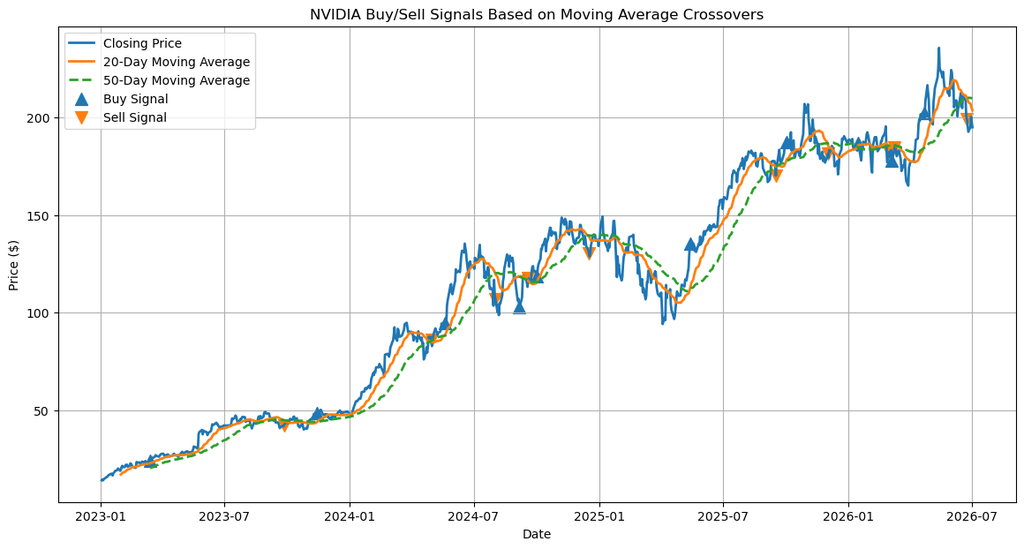

```python
plt.figure(figsize=(14,7))

plt.plot(nvda["Close"], label="Closing Price", linewidth=2)
plt.plot(nvda["MA20"], label="20-Day Moving Average", linewidth=2)
plt.plot(nvda["MA50"], label="50-Day Moving Average", linewidth=2, linestyle="--")

plt.scatter(buy_signals.index, buy_signals["Close"], label="Buy Signal", marker="^", s=100)

plt.scatter(sell_signals.index, sell_signals["Close"], label="Sell Signal", marker="v", s=100)

plt.title("NVIDIA Buy/Sell Signals Based on Moving Average Crossovers")
plt.xlabel("Date")
plt.ylabel("Price ($)")
plt.legend()
plt.grid(True)
plt.show()
```

## 24. Create Machine Learning Target

Tomorrow’s closing price is shifted into the current row to create the basis for supervised machine learning.

```python
nvda["Tomorrow Close"] = close.shift(-1)

print(nvda[["Close", "Tomorrow Close"]].head(10))
```

```
Price           Close Tomorrow Close
Ticker           NVDA
Date
2023-01-03  14.283261      14.716302
2023-01-04  14.716302      14.233374
2023-01-05  14.233374      14.826057
2023-01-06  14.826057      15.593353
2023-01-09  15.593353      15.873730
2023-01-10  15.873730      15.965526
2023-01-11  15.965526      16.474392
2023-01-12  16.474392      16.861534
2023-01-13  16.861534      17.662754
2023-01-17  17.662754      17.338476
```

## 25. Create Target Variable

The target variable `Tomorrow Up` is created. A value of 1 means the next day closed higher, and 0 means it did not.

```python
nvda["Tomorrow Up"] = (nvda["Tomorrow Close"] > close).astype(int)

print(nvda[["Close", "Tomorrow Close", "Tomorrow Up"]].head(10))
```

```
Price           Close Tomorrow Close Tomorrow Up
Ticker           NVDA
Date
2023-01-03  14.283261      14.716302           1
2023-01-04  14.716302      14.233374           0
2023-01-05  14.233374      14.826057           1
2023-01-06  14.826057      15.593353           1
2023-01-09  15.593353      15.873730           1
2023-01-10  15.873730      15.965526           1
2023-01-11  15.965526      16.474392           1
2023-01-12  16.474392      16.861534           1
2023-01-13  16.861534      17.662754           1
2023-01-17  17.662754      17.338476           0
```

## 26. Select Model Features

The model features are selected. These are the variables the machine learning models use to learn patterns.

```python
features = [
    "Close",
    "Volume",
    "Daily Return",
    "MA20",
    "MA50"
]

X = nvda[features]

y = nvda["Tomorrow Up"]

print(X.head())

print()

print(y.head())
```

```
Price           Close     Volume Daily Return MA20 MA50
Ticker           NVDA       NVDA
Date
2023-01-03  14.283261  401277000          NaN  NaN  NaN
2023-01-04  14.716302  431324000     0.030318  NaN  NaN
2023-01-05  14.233374  389168000    -0.032816  NaN  NaN
2023-01-06  14.826057  405044000     0.041640  NaN  NaN
2023-01-09  15.593353  504231000     0.051753  NaN  NaN

Date
2023-01-03    1
2023-01-04    0
2023-01-05    1
2023-01-06    1
2023-01-09    1
Name: Tomorrow Up, dtype: int32
```

## 27. Clean the Data

Rows with missing values are removed so the machine learning models can train on complete observations.

```python
ml_data = nvda.dropna()

print("Rows before cleaning:", len(nvda))
print("Rows after cleaning :", len(ml_data))
```

```
Rows before cleaning: 877
Rows after cleaning : 827
```

## 28. Train/Test Split

The dataset is split into training and testing data to evaluate model performance on unseen observations.

```python
from sklearn.model_selection import train_test_split

features = ["Close", "Volume", "Daily Return", "MA20", "MA50"]

X = ml_data[features]

y = ml_data["Tomorrow Up"]

X_train, X_test, y_train, y_test = train_test_split(
    X,
    y,
    test_size=0.20,
    random_state=42
)

print("Training rows:", len(X_train))
print("Testing rows :", len(X_test))
```

```
Training rows: 661
Testing rows : 166
```

## 29. Logistic Regression Model

Logistic Regression is trained as the baseline machine learning model.

```python
from sklearn.linear_model import LogisticRegression

model = LogisticRegression(max_iter=1000)


model.fit(X_train, y_train)

print("Model training complete!")
```

```
Model training complete!
```

## 30. Make Predictions

The trained Logistic Regression model is used to make predictions on the test dataset.

```python
predictions = model.predict(X_test)

print(predictions[:20])
```

```
[1 1 1 1 1 1 1 1 1 1 1 1 0 1 1 1 1 1 1 1]
```

## 31. Model Accuracy

The Logistic Regression model is evaluated using accuracy.

```python
from sklearn.metrics import accuracy_score

accuracy = accuracy_score(y_test, predictions)

print(f"Model Accuracy: {accuracy:.2%}")
```

```
Model Accuracy: 54.22%
```

## 32. Random Forest Model

A Random Forest classifier is trained and evaluated for comparison.

```python
from sklearn.ensemble import RandomForestClassifier

rf_model = RandomForestClassifier(
    n_estimators=100,
    random_state=42
)

rf_model.fit(X_train, y_train)

rf_predictions = rf_model.predict(X_test)

from sklearn.metrics import accuracy_score

rf_accuracy = accuracy_score(y_test, rf_predictions)

print(f"Random Forest Accuracy: {rf_accuracy:.2%}")
```

```
Random Forest Accuracy: 53.01%
```

## 33. XGBoost Model

An XGBoost classifier is trained and evaluated. This model produced the strongest result in this project.

```python
from xgboost import XGBClassifier

xgb_model = XGBClassifier(
    n_estimators=100,
    random_state=42,
    eval_metric="logloss"
)

xgb_model.fit(X_train, y_train)

xgb_predictions = xgb_model.predict(X_test)

from sklearn.metrics import accuracy_score

xgb_accuracy = accuracy_score(y_test, xgb_predictions)

print(f"XGBoost Accuracy: {xgb_accuracy:.2%}")
```

```
XGBoost Accuracy: 59.04%
```

## 34. Final Next-Day Prediction

The best-performing model is used to generate a final next-day directional prediction and probability estimate.

```python
latest_data = ml_data[features].tail(1)

prediction = xgb_model.predict(latest_data)

probability = xgb_model.predict_proba(latest_data)

print("Prediction for Tomorrow:")

if prediction[0] == 1:
    print("Model predicts: UP")
else:
    print("Model predicts: DOWN")

print(f"Probability Down: {probability[0][0]:.2%}")
print(f"Probability Up  : {probability[0][1]:.2%}")
```

```
Prediction for Tomorrow:
Model predicts: DOWN
Probability Down: 87.39%
Probability Up  : 12.61%
```

## 35. Conclusion

This project demonstrates an end-to-end machine learning workflow using real financial market data. The analysis includes data collection, feature engineering, visualization, model training, model comparison, and final prediction.

The strongest model in this version was **XGBoost**, which outperformed Logistic Regression and Random Forest on the test dataset. Future improvements may include additional technical indicators, earnings data, news sentiment, relative volume, and intraday opening-hour behavior analysis.

**Important note:** This project is for educational and portfolio purposes only. It is not financial advice.